# test log-transformation

# plot implications

```r
y <- d$c_5
y_0 <- posterior_predict(negbin_post_log_0, draws = 500)
y_1 <- posterior_predict(negbin_post_log_1, draws = 500)
y_01 <- posterior_predict(negbin_post_log_01, draws = 500)
```

## no intercept

looks pretty good. Does overestimate number of 1, and underestimate number of 2 & 3 a bit (always does) – perhaps zero-inflated better? a lot of uncertainty around 0 and 1 still.

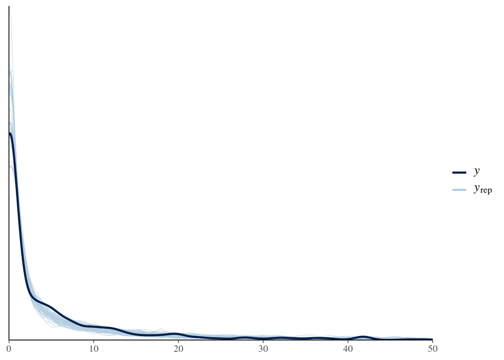

```r
ppc_dens_overlay(y, y_0[1:50, ]) + xlim(0, 50)
```

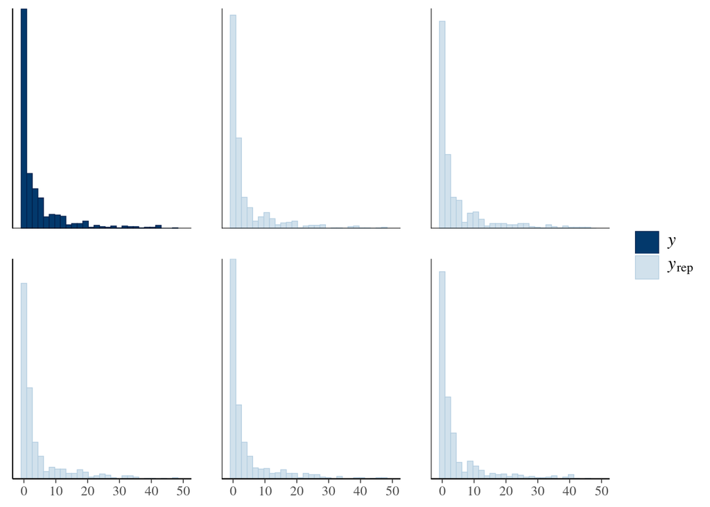

```r
ppc_hist(y, y_0[1:5, ]) + xlim(-1, 50)
```

## regular intercept

Perhaps a bit worse (e.g. with the undershoot at around c_5 = 5).

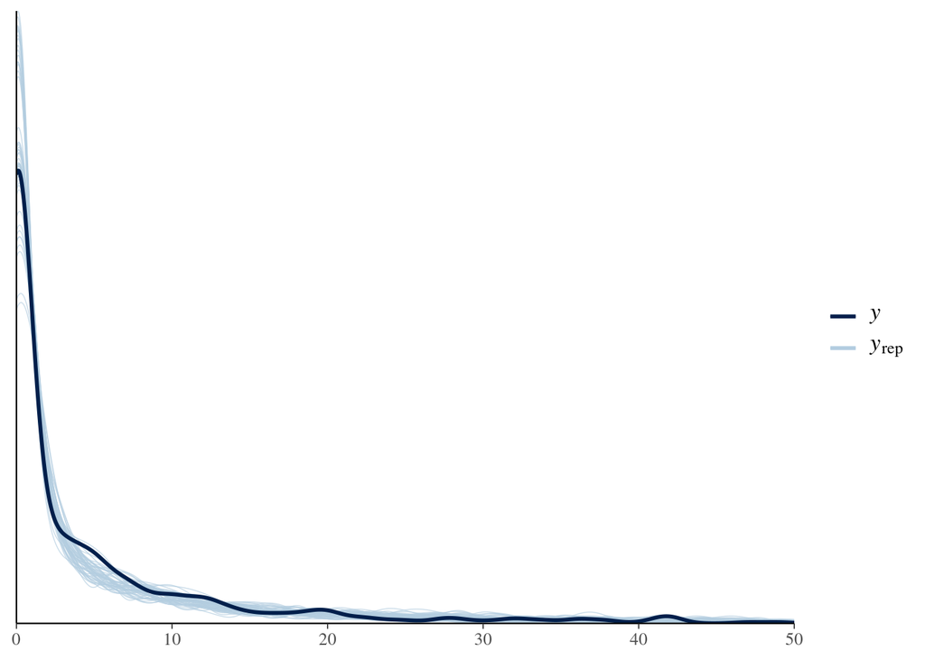

```r
ppc_dens_overlay(y, y_1[1:50, ]) + xlim(0, 50)
```

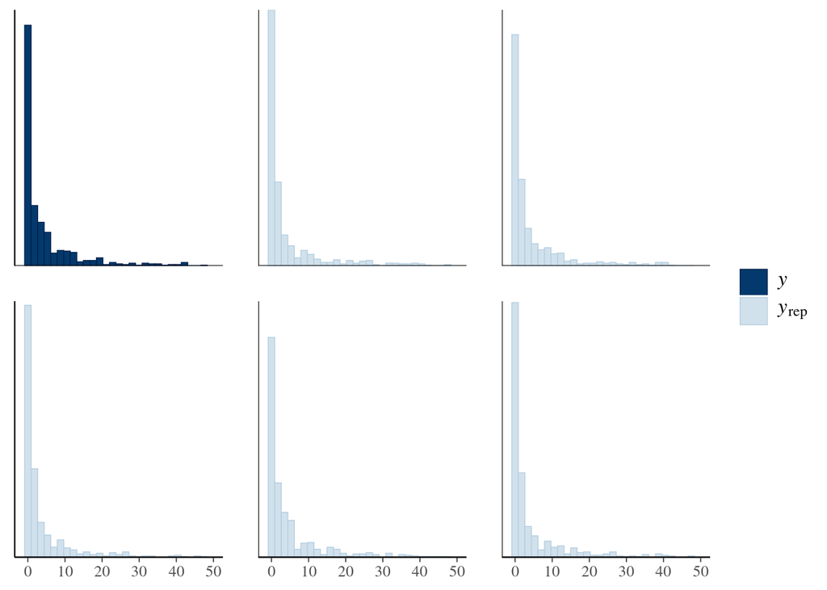

```r
ppc_hist(y, y_1[1:5, ]) + xlim(-1, 50)
```

## 0 + Intercept

Looks more or less the same.

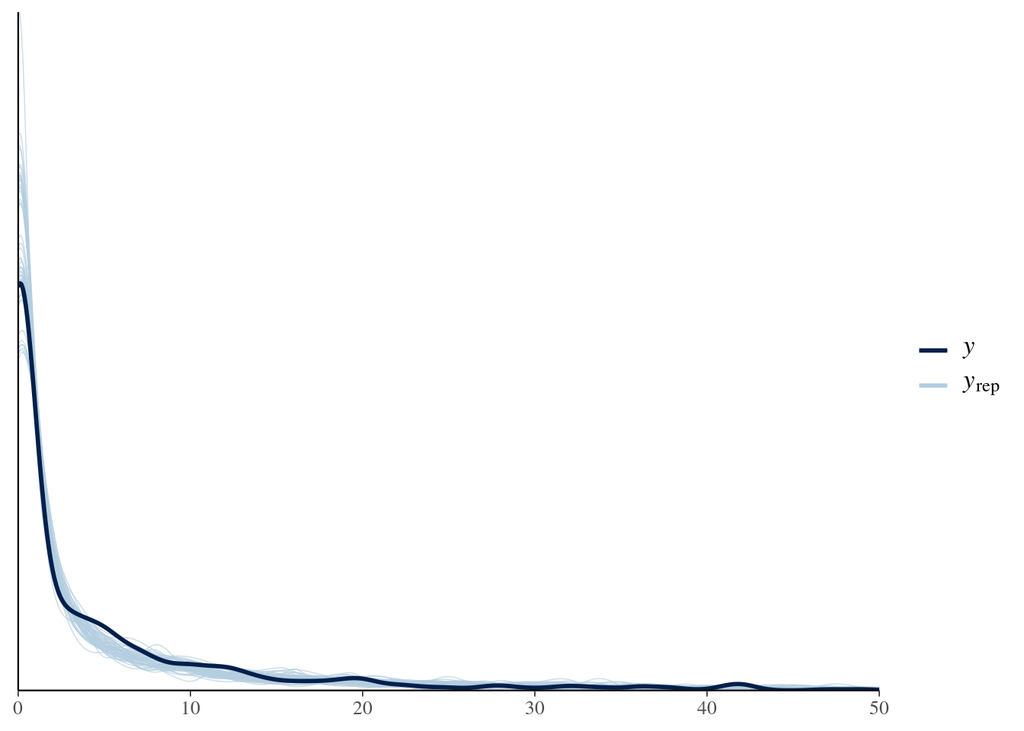

```r
ppc_dens_overlay(y, y_01[1:50, ]) + xlim(0, 50)
```

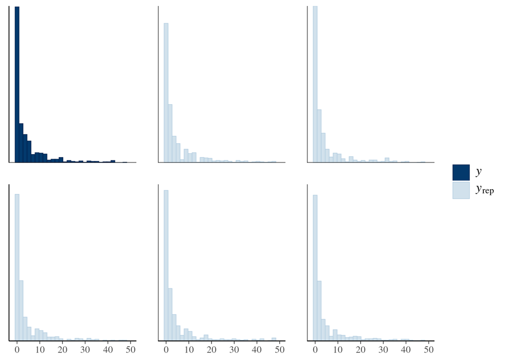

```r
ppc_hist(y, y_01[1:5, ]) + xlim(-1, 50)
```

# pareto k issues

https://bookdown.org/content/4857/monsters-and-mixtures.html

## no intercept

Mainly studies that are (relatively) low teamsize and high citation. Also, several control studies that are the same (c_5 = 77, teamsize_log = 0.693, condition = control). Really need to fix this in the preprocessing. But here, we basically get that all studies with many citations are influential…

```r
d %>%
  mutate(k = negbin_post_log_0$criteria$loo$diagnostics$pareto_k) %>%
  filter(k > .7) %>%
  select(c_5, teamsize_log, condition_fct, id_match, k)
```

```
## # A tibble: 17 × 5
##      c_5 teamsize_log condition_fct id_match     k
##    <dbl>        <dbl> <fct>         <fct>    <dbl>
##  1    30        1.39  experiment    32       0.765
##  2    88        1.61  control       106      0.706
##  3    77        0.693 control       182      0.960
##  4    77        0.693 control       183      0.837
##  5    77        0.693 control       184      0.708
##  6    77        0.693 control       185      0.759
##  7    77        0.693 control       187      0.712
##  8    77        0.693 control       188      0.817
##  9    17        1.39  experiment    193      0.726
## 10    27        0     experiment    194      0.786
## 11    87        0     experiment    206      0.748
## 12    76        0.693 experiment    211      0.796
## 13   129        3.93  experiment    222      0.744
## 14    38        1.79  experiment    232      0.739
## 15    41        0.693 experiment    256      0.727
## 16    98        0.693 experiment    271      0.790
## 17    76        1.10  experiment    310      0.704
```

## 1 + …

some of the same here, mainly studies with high c_5 and low teamsize.

```r
d %>%
  mutate(k = negbin_post_log_1$criteria$loo$diagnostics$pareto_k) %>%
  filter(k > .7) %>%
  select(c_5, teamsize_log, condition_fct, id_match, k)
```

```
## # A tibble: 19 × 5
##      c_5 teamsize_log condition_fct id_match     k
##    <dbl>        <dbl> <fct>         <fct>    <dbl>
##  1     9        1.39  control       29       0.725
##  2    78        1.95  experiment    36       0.782
##  3    88        1.61  control       106      0.731
##  4    77        0.693 control       182      0.783
##  5    77        0.693 control       184      0.772
##  6    77        0.693 control       186      0.781
##  7    77        0.693 control       187      0.823
##  8    77        0.693 control       188      0.829
##  9    27        0     experiment    194      0.790
## 10    87        0     experiment    206      0.714
## 11    76        0.693 experiment    211      0.724
## 12   129        3.93  experiment    222      0.725
## 13    47        2.40  experiment    234      0.795
## 14    32        1.61  control       247      0.730
## 15    74        1.95  experiment    284      0.781
## 16     4        0.693 experiment    288      0.709
## 17    76        1.10  experiment    310      0.745
## 18     6        1.39  experiment    342      0.815
## 19    19        0.693 control       346      0.721
```

## 0 + Intercept

Seems to handle influential observations a bit better. Still issue with the repeated value as above & some “experiment”-condition. Primarily those with high c_5.

```r
# two studies that are the same in control (issue to be resolved earlier in the pipeline).
# the outlier study (experiment) which is max in teamsize and also extremely high citation
# whereas the
d %>%
  mutate(k = negbin_post_log_01$criteria$loo$diagnostics$pareto_k) %>%
  filter(k > .7) %>%
  select(c_5, teamsize_log, condition_fct, id_match, k)
```

```
## # A tibble: 14 × 5
##      c_5 teamsize_log condition_fct id_match     k
##    <dbl>        <dbl> <fct>         <fct>    <dbl>
##  1   133        1.39  experiment    7        0.836
##  2     7        1.61  experiment    71       0.712
##  3    77        0.693 control       182      0.715
##  4    77        0.693 control       183      0.714
##  5    77        0.693 control       184      0.767
##  6    77        0.693 control       185      0.724
##  7    77        0.693 control       187      0.814
##  8    77        0.693 control       188      0.941
##  9    87        0     experiment    206      0.767
## 10    76        0.693 experiment    211      0.806
## 11    47        2.40  experiment    234      0.743
## 12    76        1.10  experiment    310      0.716
## 13     7        0     experiment    331      0.703
## 14    75        1.39  experiment    386      0.807
```

# Quick model comparison

```r
loo_compare(negbin_post_log_0,
            negbin_post_log_1,
            negbin_post_log_01)
```

```
##                    elpd_diff se_diff
## negbin_post_log_01  0.0       0.0
## negbin_post_log_0  -0.1       0.7
## negbin_post_log_1  -0.5       0.6
```

```r
loo_model_weights(negbin_post_log_0,
                  negbin_post_log_1,
                  negbin_post_log_01)
```

```
## Method: stacking
## ------
##                    weight
## negbin_post_log_0  0.335
## negbin_post_log_1  0.000
## negbin_post_log_01 0.665
```